# Analysis: Google Search Interest in Immigration-Related Topics vs Electoral Swing Per County

Dowland Aiello, Roy Lin, Winston Qi

2025-06-08

## 1. Overview

Herein, we explore the relationship between google search query frequency for topics related to immigration and the electoral swing in the Presidential election at a given point in time. We are particularly interested in the relationship between the change in search frequency and the magnitude of the electoral swinng.

## 2. Data Cleaning

See the `scripts/` folder for utilities we wrote to clean our data. Notably, Google trends data for city / region over varying time frames were combined from multiple CSV files into a single table, which looks like this:

```r
library(dplyr)
library(purrr)
library(tidyr)
library(stringr)

trendsdf <- read.csv("../../data_cleaned/google_trends/summarized.csv")
trendsdf %>% head(5)
```

```
##   X                                      DMA daterange query_incidence
## 1 1                     Yuma AZ-El Centro CA     04-08             100
## 2 2                  Miami-Ft. Lauderdale FL     04-08              84
## 3 3 Harlingen-Weslaco-Brownsville-McAllen TX     04-08              74
## 4 4                                Alpena MI     04-08              73
## 5 5            Washington DC (Hagerstown MD)     04-08              72
```

## 3. Electoral Swing from 2004 - 2008 Presidential Elections

### 3.1 Data Overview

Here is an overview of the electiondf dataset:

```r
electiondf <- read.csv("../../data_cleaned/harvard_election/countypres_2000-2020.csv")
electiondf %>% sample_n(10)
```

```
##    year     state state_po   county_name county_fips       office
## 1  2000  MISSOURI       MO        HOWELL       29091 US PRESIDENT
## 2  2020     TEXAS       TX      GONZALES       48177 US PRESIDENT
## 3  2000 TENNESSEE       TN         LEWIS       47101 US PRESIDENT
## 4  2000   INDIANA       IN         SCOTT       18143 US PRESIDENT
## 5  2008  VIRGINIA       VA          BATH       51017 US PRESIDENT
## 6  2020  VIRGINIA       VA ISLE OF WIGHT       51093 US PRESIDENT
## 7  2012  NEW YORK       NY       STEUBEN       36101 US PRESIDENT
## 8  2004     TEXAS       TX       JACKSON       48239 US PRESIDENT
## 9  2012  KENTUCKY       KY         LOGAN       21141 US PRESIDENT
## 10 2020   INDIANA       IN         HENRY       18065 US PRESIDENT
##         candidate      party candidatevotes totalvotes  version        mode
## 1         AL GORE   DEMOCRAT           4641      14075 20220315       TOTAL
## 2  DONALD J TRUMP REPUBLICAN           5627       7648 20220315       TOTAL
## 3     RALPH NADER      GREEN             63       4420 20220315       TOTAL
## 4         AL GORE   DEMOCRAT           3915       7846 20220315       TOTAL
## 5           OTHER      OTHER             40       2432 20220315       TOTAL
## 6  DONALD J TRUMP REPUBLICAN             46      23456 20220315 PROVISIONAL
## 7     MITT ROMNEY REPUBLICAN          20163      38531 20220315       TOTAL
## 8      JOHN KERRY   DEMOCRAT           1296       5077 20220315       TOTAL
## 9     MITT ROMNEY REPUBLICAN           6899      10510 20220315       TOTAL
## 10 DONALD J TRUMP REPUBLICAN          15043      21030 20220315       TOTAL
```

### 3.2 Data Cleaning

For this particular analysis, we are interested in the swing from 2004 to 2008. We can get all data from these date ranges like such:

```r
electiondf %>%
    filter(year == 2004 | year == 2008) %>%
    sample_n(5)
```

```
##   year      state state_po county_name county_fips       office  candidate
## 1 2004   NEW YORK       NY      ULSTER       36111 US PRESIDENT JOHN KERRY
## 2 2008    FLORIDA       FL   LAFAYETTE       12067 US PRESIDENT      OTHER
## 3 2004 CALIFORNIA       CA      LASSEN        6035 US PRESIDENT JOHN KERRY
## 4 2004    VERMONT       VT  WASHINGTON       50023 US PRESIDENT JOHN KERRY
## 5 2004      TEXAS       TX        BELL       48027 US PRESIDENT      OTHER
##      party candidatevotes totalvotes  version  mode
## 1 DEMOCRAT          45530      87712 20220315 TOTAL
## 2    OTHER             38       3359 20220315 TOTAL
## 3 DEMOCRAT           3158      11437 20220315 TOTAL
## 4 DEMOCRAT          19177      31448 20220315 TOTAL
## 5    OTHER            424      79724 20220315 TOTAL
```

We can gather all votes in 2004 and 2008 per county via the pivot function:

```r
votestimeframe <- electiondf %>%
  select(year, state, county_name, party, office, candidatevotes, totalvotes) %>%
  # Select only republican so that further analysis can have red/blue as meaningful colors
  filter(office == "US PRESIDENT") %>%
  # Collapse votes in year n, n1 into columns n, n1
  group_by(year, state, county_name, office, party) %>%
  summarise(year, state, county_name, candidatevotes) %>%
  ungroup() %>%
  distinct(party, state, county_name, year, .keep_all = TRUE) %>%
  select(party, state, county_name, year, candidatevotes) %>%
  pivot_wider(id_cols = c(state, county_name), names_from = c(party, year), values_from = c(candidatevotes))
```

[output not shown]

```r
votestimeframe %>% head(10)
```

```
## # A tibble: 10 × 23
##    state   county_name DEMOCRAT_2000 GREEN_2000 OTHER_2000 REPUBLICAN_2000
##    <chr>   <chr>               <int>      <int>      <int>           <int>
##  1 ALABAMA AUTAUGA              4942        160        113           11993
##  2 ALABAMA BALDWIN             13997       1033        578           40872
##  3 ALABAMA BARBOUR              5188         46         65            5096
##  4 ALABAMA BIBB                 2710         52         66            4273
##  5 ALABAMA BLOUNT               4977        154        175           12667
##  6 ALABAMA BULLOCK              3395         24         52            1433
##  7 ALABAMA BUTLER               3606         36         34            4127
##  8 ALABAMA CALHOUN             15781        481        341           22306
##  9 ALABAMA CHAMBERS             5616         95         86            6037
## 10 ALABAMA CHEROKEE             3497         77         95            4154
## # ℹ 17 more variables: DEMOCRAT_2004 <int>, OTHER_2004 <int>,
## #   REPUBLICAN_2004 <int>, DEMOCRAT_2008 <int>, OTHER_2008 <int>,
## #   REPUBLICAN_2008 <int>, DEMOCRAT_2012 <int>, OTHER_2012 <int>,
## #   REPUBLICAN_2012 <int>, DEMOCRAT_2016 <int>, OTHER_2016 <int>,
## #   REPUBLICAN_2016 <int>, DEMOCRAT_2020 <int>, OTHER_2020 <int>,
## #   REPUBLICAN_2020 <int>, GREEN_2020 <int>, LIBERTARIAN_2020 <int>
```

### 3.3 Swing Calculation

We can then calculate the swing like such:

```r
votestimeframe %>%
    group_by(state, county_name) %>%
    summarise(swing = .data[["REPUBLICAN_2008"]] - .data[["REPUBLICAN_2004"]]) %>%
    head(10)
```

```
## # A tibble: 10 × 3
## # Groups:   state [1]
##    state   county_name swing
##    <chr>   <chr>       <int>
##  1 ALABAMA AUTAUGA      2207
##  2 ALABAMA BALDWIN      8300
##  3 ALABAMA BARBOUR       -33
##  4 ALABAMA BIBB          790
##  5 ALABAMA BLOUNT       3003
##  6 ALABAMA BULLOCK      -103
##  7 ALABAMA BUTLER        506
##  8 ALABAMA CALHOUN      2534
##  9 ALABAMA CHAMBERS      445
## 10 ALABAMA CHEROKEE     1375
```

## 4. Change in Google Trends Over a Timeframe

### 4.1 Change Overview

Now, we calculate the change in average query incidence from one timeframe to the next. We use a similar pivoting method to get (date ranges, queyr_incidence) as columns.

```r
trendsdf %>%
  pivot_wider(id_cols = c(DMA), names_from = daterange, values_from = query_incidence, values_fn = max) %>%
  (\(df) df %>% mutate("change_04-12" = df[["08-12"]] - df[["04-08"]])) %>%
  head(10)
```

```
## # A tibble: 10 × 15
##    DMA   `04-08` `08-12` `12-16` `16-20` `20-24` `16-17` `17-18` `18-19` `19-20`
##    <chr>   <int>   <int>   <int>   <int>   <int>   <int>   <int>   <int>   <int>
##  1 Yuma…     100      68      64      68      55      67      68      68      68
##  2 Miam…      84      84      92      98     100     100     100     100     100
##  3 Harl…      74     100      65      80      66      82      90      76      74
##  4 Alpe…      73      34      22      25      15      27      33      24      32
##  5 Wash…      72      63      91     100      80      86      95      82      91
##  6 New …      71      73     100      87      76      91      86      79      86
##  7 El P…      71      92      68      75      78      76      79      84      78
##  8 West…      69      72      81      81      76      77      76      74      73
##  9 Bang…      67      40      31      32      24      40      43      43      34
## 10 Los …      67      67      74      71      66      89      76      71      79
## # ℹ 5 more variables: `20-21` <int>, `21-22` <int>, `22-23` <int>,
## #   `23-24` <int>, `change_04-12` <int>
```

### 4. Generic Function

Now, we make a reusable function which calculates the change over a given time period for all regions.

```r
change_time_period <- function(date1, date2) {
  trendsdf %>%
    pivot_wider(id_cols = c(DMA), names_from = daterange, values_from = query_incidence, values_fn = max) %>%
    mutate("change_query_incidence" = .data[[date1]] - .data[[date2]])
}

change_time_period("08-12", "04-08") %>% head(10)
```

```
## # A tibble: 10 × 15
##    DMA   `04-08` `08-12` `12-16` `16-20` `20-24` `16-17` `17-18` `18-19` `19-20`
##    <chr>   <int>   <int>   <int>   <int>   <int>   <int>   <int>   <int>   <int>
##  1 Yuma…     100      68      64      68      55      67      68      68      68
##  2 Miam…      84      84      92      98     100     100     100     100     100
##  3 Harl…      74     100      65      80      66      82      90      76      74
##  4 Alpe…      73      34      22      25      15      27      33      24      32
##  5 Wash…      72      63      91     100      80      86      95      82      91
##  6 New …      71      73     100      87      76      91      86      79      86
##  7 El P…      71      92      68      75      78      76      79      84      78
##  8 West…      69      72      81      81      76      77      76      74      73
##  9 Bang…      67      40      31      32      24      40      43      43      34
## 10 Los …      67      67      74      71      66      89      76      71      79
## # ℹ 5 more variables: `20-21` <int>, `21-22` <int>, `22-23` <int>,
## #   `23-24` <int>, change_query_incidence <int>
```

```r
change_time_period("16-17", "19-20") %>% head(10)
```

```
## # A tibble: 10 × 15
##    DMA   `04-08` `08-12` `12-16` `16-20` `20-24` `16-17` `17-18` `18-19` `19-20`
##    <chr>   <int>   <int>   <int>   <int>   <int>   <int>   <int>   <int>   <int>
##  1 Yuma…     100      68      64      68      55      67      68      68      68
##  2 Miam…      84      84      92      98     100     100     100     100     100
##  3 Harl…      74     100      65      80      66      82      90      76      74
##  4 Alpe…      73      34      22      25      15      27      33      24      32
##  5 Wash…      72      63      91     100      80      86      95      82      91
##  6 New …      71      73     100      87      76      91      86      79      86
##  7 El P…      71      92      68      75      78      76      79      84      78
##  8 West…      69      72      81      81      76      77      76      74      73
##  9 Bang…      67      40      31      32      24      40      43      43      34
## 10 Los …      67      67      74      71      66      89      76      71      79
## # ℹ 5 more variables: `20-21` <int>, `21-22` <int>, `22-23` <int>,
## #   `23-24` <int>, change_query_incidence <int>
```

## 5. Heatmap: Query Incidence Swing vs Electoral Swing (2004 election to 2012 election)

### 5.1 Data Overview

We first match cities from Google trends to electoral data. We do so by checking for cities in the election data which are substrings of the Google trends DMA column. Note that the line of code for doing a fuzzy merge uses the fuzzyjoin package.

```r
library(fuzzyjoin)

interest_swing_08_12 <- change_time_period("08-12", "04-08") %>% mutate(county = toupper(DMA)) %>% select(county, change_query_incidence)
swing_county <- votestimeframe %>%
    group_by(state, county_name) %>%
    summarise(swing = .data[["REPUBLICAN_2012"]] / (.data[["REPUBLICAN_2012"]] + .data[["DEMOCRAT_2012"]]) - .data[["REPUBLICAN_2004"]] / (.data[["REPUBLICAN_2004"]] + .data[["DEMOCRAT_2004"]])) %>%
    mutate(county = county_name) %>%
    select(county, swing)
regex_inner_join(interest_swing_08_12, swing_county, by = "county") %>% head(10)
```

```
## # A tibble: 10 × 5
##    county.x                       change_query_incidence state county.y    swing
##    <chr>                                           <int> <chr> <chr>       <dbl>
##  1 YUMA AZ-EL CENTRO CA                              -32 ARIZ… YUMA     -0.0166
##  2 YUMA AZ-EL CENTRO CA                              -32 COLO… YUMA      0.0149
##  3 MIAMI-FT. LAUDERDALE FL                             0 ALAB… DALE     -0.0397
##  4 MIAMI-FT. LAUDERDALE FL                             0 ALAB… LAUDERD…  0.0541
##  5 MIAMI-FT. LAUDERDALE FL                             0 INDI… MIAMI    -0.0524
##  6 MIAMI-FT. LAUDERDALE FL                             0 KANS… MIAMI     0.0259
##  7 MIAMI-FT. LAUDERDALE FL                             0 MISS… LAUDERD… -0.0841
##  8 MIAMI-FT. LAUDERDALE FL                             0 OHIO  MIAMI     0.0199
##  9 MIAMI-FT. LAUDERDALE FL                             0 TENN… LAUDERD…  0.0530
## 10 HARLINGEN-WESLACO-BROWNSVILLE…                     26 ILLI… BROWN     0.00553
```

Looks good.

### 5.2 The Heatmap

```r
library(ggmap)
register_google(key = Sys.getenv("GOOGLE_API_KEY"), write = FALSE)

with_lat_long <- regex_inner_join(interest_swing_08_12, swing_county, by = "county") %>%
    select(county = county.y, swing, change_query_incidence, state) %>%
    (\(df) df %>% mutate(lat_long = geocode(output = "latlon", location = paste(df$county, ", ", df$state), method = "census")))
with_lat_long %>% write.csv("../../data_cleaned/swing_interest_vs_electoral_04_12_lat_long.csv")
with_lat_long %>% head(10)
```

```
## # A tibble: 10 × 5
##    county        swing change_query_incidence state       lat_long$lon  $lat
##    <chr>         <dbl>                  <int> <chr>              <dbl> <dbl>
##  1 YUMA       -0.0166                     -32 ARIZONA           -115.   32.7
##  2 YUMA        0.0149                     -32 COLORADO          -103.   40.1
##  3 DALE       -0.0397                       0 ALABAMA            -85.7  31.5
##  4 LAUDERDALE  0.0541                       0 ALABAMA            -87.7  34.9
##  5 MIAMI      -0.0524                       0 INDIANA            -86.1  40.6
##  6 MIAMI       0.0259                       0 KANSAS             -94.8  38.6
##  7 LAUDERDALE -0.0841                       0 MISSISSIPPI        -88.5  32.5
##  8 MIAMI       0.0199                       0 OHIO               -84.7  39.5
##  9 LAUDERDALE  0.0530                       0 TENNESSEE          -89.7  35.8
## 10 BROWN       0.00553                     26 ILLINOIS           -90.7  39.9
```

```r
with_lat_long <- read.csv("../../data_cleaned/swing_interest_vs_electoral_04_12_lat_long.csv") %>%
    mutate(lat = lat_long.lat, long = lat_long.lon) %>%
    arrange(lat, long)
with_corr <- with_lat_long %>%
    filter(!is.na(change_query_incidence) & !is.na(swing))

with_corr %>% select(change_query_incidence, swing, lat, long) %>% head(10)
```

```
##    change_query_incidence         swing      lat       long
## 1                       5 -0.1838277000 21.30988 -157.85814
## 2                       1  0.0001901139 25.29745  -81.07547
## 3                       3  0.0215016900 26.70562  -80.03643
## 4                       0  0.0074100420 26.89460  -81.90983
## 5                       7  0.0074100420 26.89460  -81.90983
## 6                       8 -0.0046585390 27.33647  -82.53101
## 7                       8 -0.0155437200 28.32324  -82.43194
## 8                      14 -0.0202440100 28.70285  -81.77870
## 9                       4 -0.0202440100 28.70285  -81.77870
## 10                      3 -0.0182655700 28.80527  -97.00360
```

Looks good. Now, we generate the heatmap.

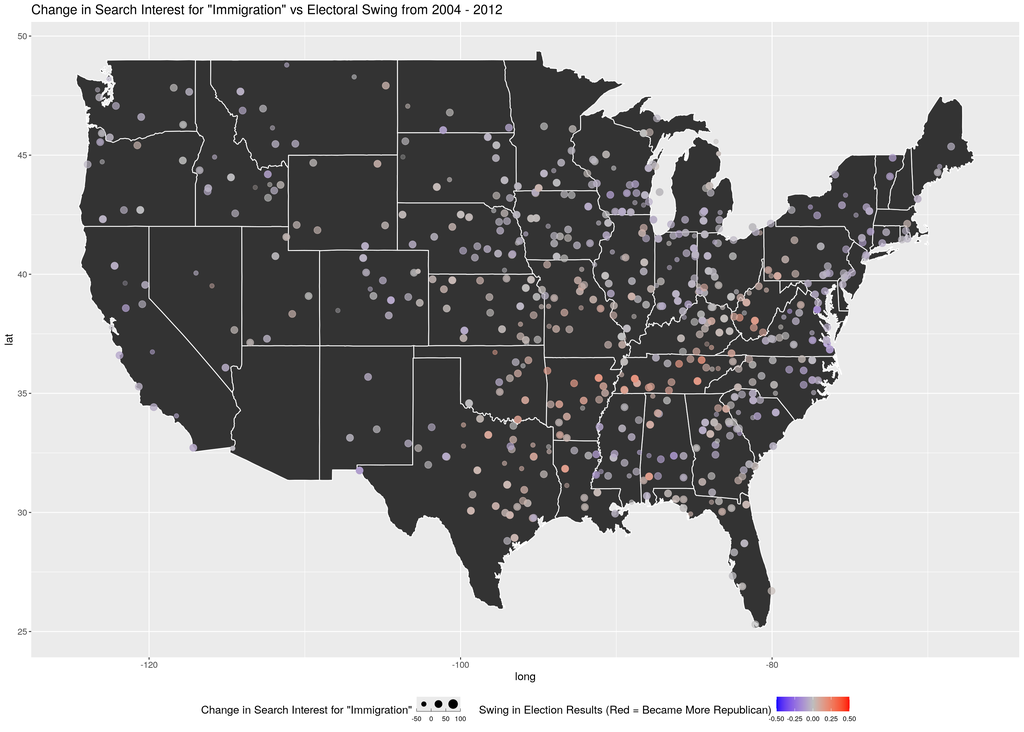

```r
library(maps)
library(ggplot2)
library(scales)
plot <- ggplot(data = map_data("state") %>% filter(long > -140)) +
  geom_polygon(aes(x = long, y = lat, group = group), color = "white") +
  geom_point(data = with_corr %>% filter(long > -140), aes(x = long, y = lat, color = as.numeric(swing), alpha = as.numeric(change_query_incidence), size = as.numeric(change_query_incidence))) +
  scale_colour_gradient2(low = "blue", high = "red", mid = "gray", midpoint = 0, limits=c(-0.5, 0.5)) +
  labs(
    title = "Change in Search Interest for \"Immigration\" vs Electoral Swing from 2004 - 2012",
    color = "Swing in Election Results (Red = Became More Republican)",
    size = "Change in Search Interest for \"Immigration\"",
  ) +
  guides(alpha = "none") +
  scale_alpha(range = c(0.05, 1), limits = c(-30, 20)) +
  scale_size_binned(n.breaks = 5, range = c(0.25, 5), limits = c(-50, 100)) +
  theme(text = element_text(size = 13), legend.text = element_text(size = 8), legend.position = "bottom")

ggsave("election_04_to_2012_heat_map_query_change_election_result.png", bg = "white")
plot
```

```r
library(fuzzyjoin)

interest_swing_08_12_16_20 <- change_time_period("08-12", "16-20") %>% mutate(county = toupper(DMA)) %>% select(county, change_query_incidence)
swing_county <- votestimeframe %>%
    group_by(state, county_name) %>%
    summarise(swing = abs(.data[["REPUBLICAN_2016"]] / (.data[["REPUBLICAN_2016"]] + .data[["DEMOCRAT_2016"]]) - .data[["REPUBLICAN_2008"]] / (.data[["REPUBLICAN_2008"]] + .data[["DEMOCRAT_2008"]]))) %>%
    mutate(county = county_name) %>%
    select(county, swing)
regex_inner_join(interest_swing_08_12_16_20, swing_county, by = "county") %>% head(10)
```

```
## # A tibble: 10 × 5
##    county.x                         change_query_incidence state county.y  swing
##    <chr>                                             <int> <chr> <chr>     <dbl>
##  1 YUMA AZ-EL CENTRO CA                                  0 ARIZ… YUMA     0.0641
##  2 YUMA AZ-EL CENTRO CA                                  0 COLO… YUMA     0.0950
##  3 MIAMI-FT. LAUDERDALE FL                             -14 ALAB… DALE     0.0329
##  4 MIAMI-FT. LAUDERDALE FL                             -14 ALAB… LAUDERD… 0.0935
##  5 MIAMI-FT. LAUDERDALE FL                             -14 INDI… MIAMI    0.184
##  6 MIAMI-FT. LAUDERDALE FL                             -14 KANS… MIAMI    0.0945
##  7 MIAMI-FT. LAUDERDALE FL                             -14 MISS… LAUDERD… 0.0166
##  8 MIAMI-FT. LAUDERDALE FL                             -14 OHIO  MIAMI    0.0934
##  9 MIAMI-FT. LAUDERDALE FL                             -14 TENN… LAUDERD… 0.0821
## 10 HARLINGEN-WESLACO-BROWNSVILLE-M…                     20 ILLI… BROWN    0.180
```

Now, we geocode the data.

```r
library(ggmap)

register_google(key = Sys.getenv("GOOGLE_API_KEY"), write = FALSE)
with_lat_long <- regex_inner_join(interest_swing_08_12_16_20, swing_county, by = "county") %>%
    select(county = county.y, swing, change_query_incidence, state) %>%
    (\(df) df %>% mutate(lat_long = geocode(output = "latlon", location = paste(df$county, ", ", df$state), method = "census")))
with_lat_long %>% write.csv("../../data_cleaned/swing_interest_vs_electoral_08_20_lat_long.csv")
with_lat_long %>% head(10)
```

```
## # A tibble: 10 × 5
##    county      swing change_query_incidence state       lat_long$lon  $lat
##    <chr>       <dbl>                  <int> <chr>              <dbl> <dbl>
##  1 YUMA       0.0641                      0 ARIZONA           -115.   32.7
##  2 YUMA       0.0950                      0 COLORADO          -103.   40.1
##  3 DALE       0.0329                    -14 ALABAMA            -85.7  31.5
##  4 LAUDERDALE 0.0935                    -14 ALABAMA            -87.7  34.9
##  5 MIAMI      0.184                     -14 INDIANA            -86.1  40.6
##  6 MIAMI      0.0945                    -14 KANSAS             -94.8  38.6
##  7 LAUDERDALE 0.0166                    -14 MISSISSIPPI        -88.5  32.5
##  8 MIAMI      0.0934                    -14 OHIO               -84.7  39.5
##  9 LAUDERDALE 0.0821                    -14 TENNESSEE          -89.7  35.8
## 10 BROWN      0.180                      20 ILLINOIS           -90.7  39.9
```

We cache this data for convenience.

```r
library(maps)
library(ggplot2)
library(purrr)
library(scales)

with_lat_long.2 <- read.csv("../../data_cleaned/swing_interest_vs_electoral_08_20_lat_long.csv") %>%
    mutate(lat = lat_long.lat, long = lat_long.lon) %>%
    arrange(lat, long)
with_corr.2 <- with_lat_long.2 %>%
    filter(!is.na(change_query_incidence) & !is.na(swing))

with_corr.2 %>% select(change_query_incidence, swing, lat, long) %>% head(10)
```

```
##    change_query_incidence      swing      lat       long
## 1                       1 0.04799862 21.30988 -157.85814
## 2                       9 0.06065177 25.29745  -81.07547
## 3                      -9 0.03610478 26.70562  -80.03643
## 4                     -11 0.10627490 26.89460  -81.90983
## 5                     -15 0.10627490 26.89460  -81.90983
## 6                       0 0.05924176 27.33647  -82.53101
## 7                       0 0.09377816 28.32324  -82.43194
## 8                       9 0.05111386 28.70285  -81.77870
## 9                      -4 0.05111386 28.70285  -81.77870
## 10                      7 0.03678152 28.80527  -97.00360
```

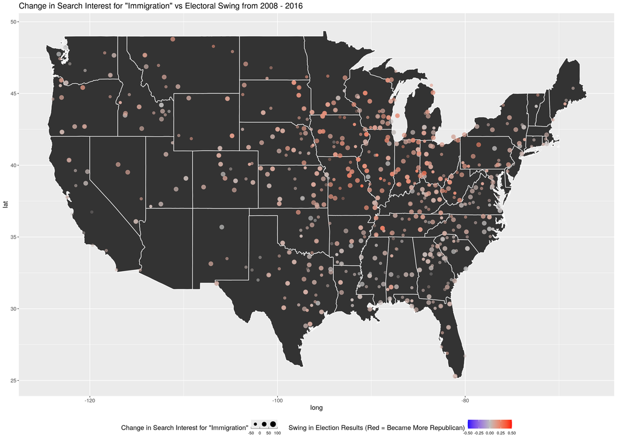

```r
plot <- ggplot(data = map_data("state") %>% filter(long > -140)) +
  geom_polygon(aes(x = long, y = lat, group = group), color = "white") +
  geom_point(data = with_corr.2 %>% filter(long > -140), aes(x = long, y = lat, color = as.numeric(swing), alpha = as.numeric(change_query_incidence), size = as.numeric(change_query_incidence))) +
  scale_colour_gradient2(low = "blue", high = "red", mid = "gray", midpoint = 0, limits=c(-0.5, 0.5)) +
  labs(
    title = "Change in Search Interest for \"Immigration\" vs Electoral Swing from 2008 - 2016",
    color = "Swing in Election Results (Red = Became More Republican)",
    size = "Change in Search Interest for \"Immigration\"",
    ) +
  guides(alpha = "none") +
  scale_alpha(range = c(0.05, 1), limits = c(-30, 20)) +
  scale_size_binned(n.breaks = 5, range = c(0.25, 5), limits = c(-50, 100)) +
  theme(text = element_text(size = 13), legend.text = element_text(size = 8), legend.position = "bottom")


ggsave("election_08_to_2020_heat_map_query_change_election_result.png", bg = "white")
plot
```

### 5.4 Comparison to 2016 - 2020 Change

Here, we generate the same heatmap, but for elections from 2016 - 2020.

```r
library(fuzzyjoin)

interest_swing_16_20 <- change_time_period("16-17", "19-20") %>% mutate(county = toupper(DMA)) %>% select(county, change_query_incidence)
swing_county <- votestimeframe %>%
    group_by(state, county_name) %>%
    summarise(swing = .data[["REPUBLICAN_2020"]] / (.data[["REPUBLICAN_2020"]] + .data[["DEMOCRAT_2020"]]) - .data[["REPUBLICAN_2016"]] / (.data[["REPUBLICAN_2016"]] + .data[["DEMOCRAT_2016"]])) %>%
    mutate(county = county_name) %>%
    select(county, swing)
regex_inner_join(interest_swing_16_20, swing_county, by = "county") %>% filter(!is.na(change_query_incidence)) %>% head(10)
```

```
## # A tibble: 10 × 5
##    county.x                       change_query_incidence state county.y    swing
##    <chr>                                           <int> <chr> <chr>       <dbl>
##  1 YUMA AZ-EL CENTRO CA                               -1 ARIZ… YUMA      0.0123
##  2 YUMA AZ-EL CENTRO CA                               -1 COLO… YUMA     -0.00181
##  3 MIAMI-FT. LAUDERDALE FL                             0 ALAB… DALE     -0.0233
##  4 MIAMI-FT. LAUDERDALE FL                             0 ALAB… LAUDERD… -0.0101
##  5 MIAMI-FT. LAUDERDALE FL                             0 INDI… MIAMI    -0.0114
##  6 MIAMI-FT. LAUDERDALE FL                             0 KANS… MIAMI    -0.0137
##  7 MIAMI-FT. LAUDERDALE FL                             0 MISS… LAUDERD… -0.0306
##  8 MIAMI-FT. LAUDERDALE FL                             0 OHIO  MIAMI    -0.0133
##  9 MIAMI-FT. LAUDERDALE FL                             0 TENN… LAUDERD…  0.0248
## 10 HARLINGEN-WESLACO-BROWNSVILLE…                      8 ILLI… BROWN     0.00843
```

Now, we geocode the data.

```r
library(ggmap)

register_google(key = Sys.getenv("GOOGLE_API_KEY"), write = FALSE)
with_lat_long <- regex_inner_join(interest_swing_16_20, swing_county, by = "county") %>%
    select(county = county.y, swing, change_query_incidence, state) %>%
    (\(df) df %>% mutate(lat_long = geocode(output = "latlon", location = paste(df$county, ", ", df$state), method = "census")))
with_lat_long %>% write.csv("../../data_cleaned/swing_interest_vs_electoral_16-20_lat_long.csv")
with_lat_long %>% head(10)
```

```
## # A tibble: 10 × 5
##    county        swing change_query_incidence state       lat_long$lon  $lat
##    <chr>         <dbl>                  <int> <chr>              <dbl> <dbl>
##  1 YUMA        0.0123                      -1 ARIZONA           -115.   32.7
##  2 YUMA       -0.00181                     -1 COLORADO          -103.   40.1
##  3 DALE       -0.0233                       0 ALABAMA            -85.7  31.5
##  4 LAUDERDALE -0.0101                       0 ALABAMA            -87.7  34.9
##  5 MIAMI      -0.0114                       0 INDIANA            -86.1  40.6
##  6 MIAMI      -0.0137                       0 KANSAS             -94.8  38.6
##  7 LAUDERDALE -0.0306                       0 MISSISSIPPI        -88.5  32.5
##  8 MIAMI      -0.0133                       0 OHIO               -84.7  39.5
##  9 LAUDERDALE  0.0248                       0 TENNESSEE          -89.7  35.8
## 10 BROWN       0.00843                      8 ILLINOIS           -90.7  39.9
```

We cache this data for convenience.

```r
library(maps)
library(ggplot2)
library(purrr)
library(scales)

with_lat_long.2 <- read.csv("../../data_cleaned/swing_interest_vs_electoral_16-20_lat_long.csv") %>%
    mutate(lat = lat_long.lat, long = lat_long.lon) %>%
    arrange(lat, long)
with_corr.2 <- with_lat_long.2 %>%
    filter(!is.na(change_query_incidence) & !is.na(swing))

with_corr.2 %>% select(change_query_incidence, swing, lat, long) %>% head(10)
```

```
##    change_query_incidence        swing      lat       long
## 1                      -3  0.023677630 21.30988 -157.85814
## 2                      -4  0.004186225 25.29745  -81.07547
## 3                       4  0.014686690 26.70562  -80.03643
## 4                       2 -0.008871271 26.89460  -81.90983
## 5                     -12 -0.008871271 26.89460  -81.90983
## 6                       0 -0.007125316 27.33647  -82.53101
## 7                      21 -0.010508870 28.32324  -82.43194
## 8                       3 -0.018074440 28.70285  -81.77870
## 9                       1 -0.018074440 28.70285  -81.77870
## 10                      0 -0.013514120 28.80527  -97.00360
```

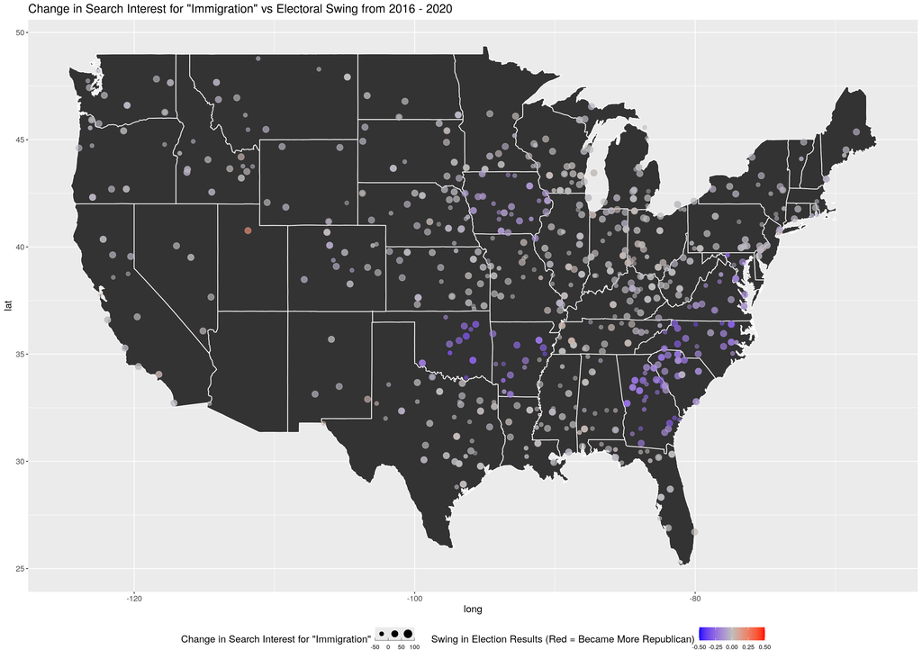

```r
plot <- ggplot(data = map_data("state") %>% filter(long > -140)) +
  geom_polygon(aes(x = long, y = lat, group = group), color = "white") +
  geom_point(data = with_corr.2 %>% filter(long > -140), aes(x = long, y = lat, color = as.numeric(swing), alpha = as.numeric(change_query_incidence), size = as.numeric(change_query_incidence))) +
  scale_colour_gradient2(low = "blue", high = "red", mid = "gray", midpoint = 0, limits=c(-0.5, 0.5)) +
  labs(
    title = "Change in Search Interest for \"Immigration\" vs Electoral Swing from 2016 - 2020",
    color = "Swing in Election Results (Red = Became More Republican)",
    size = "Change in Search Interest for \"Immigration\"",
    ) +
  guides(alpha = "none") +
  scale_alpha(range = c(0.05, 1), limits = c(-30, 20)) +
  scale_size_binned(n.breaks = 5, range = c(0.25, 5), limits = c(-50, 100)) +
  theme(text = element_text(size = 13), legend.text = element_text(size = 8), legend.position = "bottom")


ggsave("election_16_to_2020_heat_map_query_change_election_result.png", bg = "white")
plot
```